# Basking Shark Report

2026-03-26

# Introducing Brooklyn

In this report, I will be telling you all about **Brooklyn the Basking shark** (*Cetorhinus maximus*), and her journey along the eastern shore of the United States of America. During her journey through the Atlantic Ocean, Brooklyn used her **gill rakers** to feed on phytoplankton and small crustaceans within the water column.

## Selfie!

Brooklyn sent me this selfie while on her journey through the Atlantic Ocean

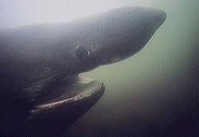

## Gill Rakers

Look at all those gill rakers!

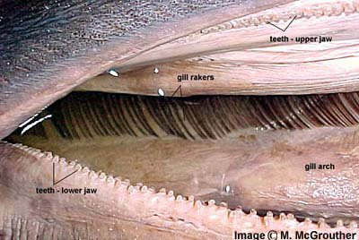

# Brooklyn’s Journey

## Map of Brooklyn’s journey

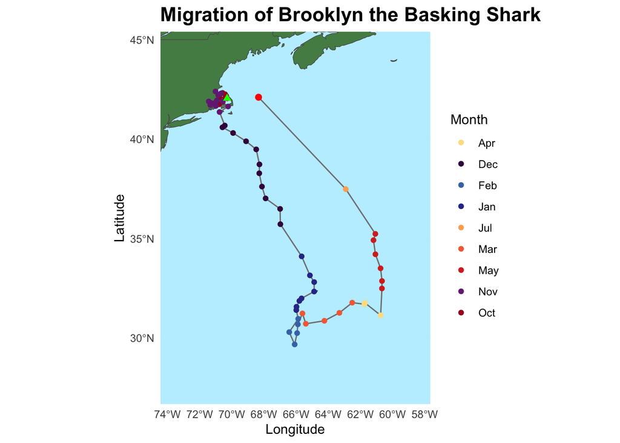

# Post-Swim Review

After all that swimming, Brooklyn derserves to be recognized for her hard work! Here is the official **breakdown**

Drumroll please….

# Brooklyn’s Journey Summary

| Starting Location | (-70.2943, 42.0470) |
| --- | --- |
| Ending Location | (-68.3400, 42.1050) |
| Latitudinal Change | 12.7214 |
| Total Distance Traveled | 2692393km |
| Maximum Depth | 1.08km |

**Wow!!!** From Oct 11, 2008 to Oct 1, 2009, Brooklyn traveled over 2 million km! That is over 4 million times the height of the CN Tower. To fuel her mission, she likely had to eat a lot of phytoplankton. On average, basking sharks filter around 2000 tons of water each day, so over the course of Brooklyn’s journey, she could have filtered over 710000 tons of water.

**Great job Brooklyn!**